# Covid-19 Overview

Yves D’hondt

28/10/2020

# Initialization

First, all the necessary packages and the most recent `coronavirus` dataset have to be loaded. The `coronavirus` dataset provided by [RamiKrispin](https://github.com/RamiKrispin/coronavirus) is used here, as well as the `pop` dataset from the `wpp2019` library about country population data.

```r
# devtools::install_github("RamiKrispin/coronavirus")
library(coronavirus)
library(dplyr)
library(ggplot2)
library(tidyverse)
library(wpp2019)
library(countrycode)
```

```r
update_dataset(silence = TRUE)
data("coronavirus")
```

# Second Wave: Belgium & Switzerland

Belgium and Switzerland are among the European countries that are hit hardest by the second wave. Let’s take a look at Belgium first.

```r
# filter data for Belgium
be.coronavirus <- coronavirus %>%
  filter(
    country == "Belgium",
    date != max(date) # in case the latest data is not yet recorded
  )

# construct Belgian plot
be.plot_overview <-
  ggplot(
    data = be.coronavirus,
    mapping = aes(x = date, y = cases)
  ) +
  geom_line(
    mapping = aes(x = date, y = cases, group = type, col = type)
  ) +
  labs(
    title = "Daily overview of Covid-19 in Belgium",
    x = "Date",
    y = "Number of cases"
  )
  NULL
```

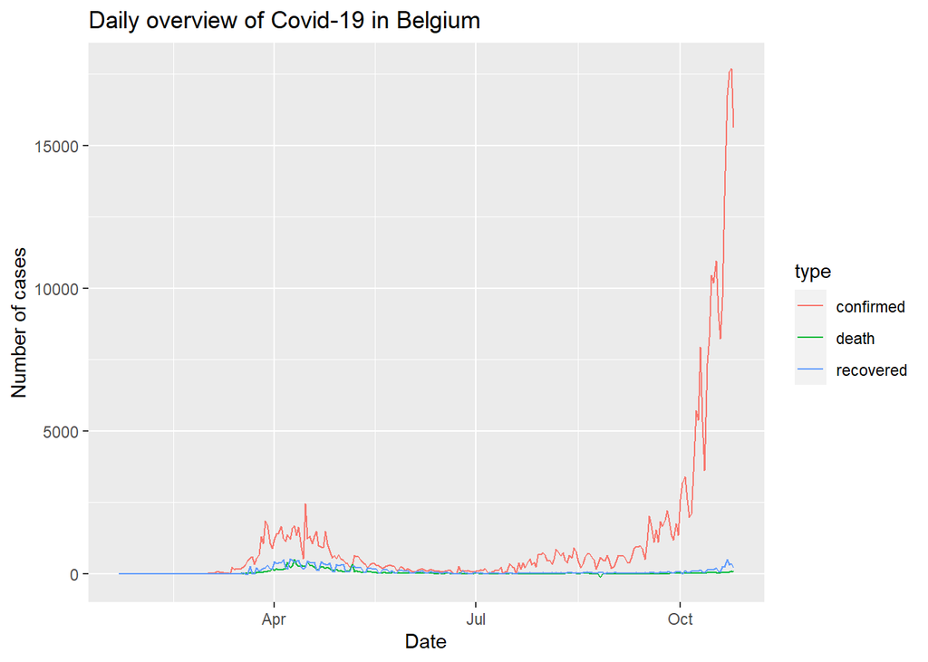

```r
# show Belgian plot
be.plot_overview
```

```r
# find the peak of confirmed cases during the first wave
be.first_peak <- be.coronavirus %>%
  filter(
    date > as.Date("2020-03-01")
    & date < as.Date("2020-06-01")
    & type == "confirmed"
  ) %>%
  summarize(
    peak = max(cases)
  )

# find the overall peak of confirmed cases
be.overall_peak <- be.coronavirus %>%
  filter(
    type == "confirmed"
  ) %>%
  summarize(
    peak = max(cases)
  )

# calculate the difference between the two peaks
be.peak_comp <- be.overall_peak$peak / be.first_peak$peak
```

The current peak is much higher than the peak from the first wave. With 2454 cases in the first wave’s peak and 17709 cases in the most recent wave’s peak, the most recent peak has around 7 times more cases than the first peak.

Let’s take a look at Switzerland next.

```r
# filter data for Switzerland
ch.coronavirus <- coronavirus %>%
  filter(
    country == "Switzerland",
    date != max(date) # in case the latest data is not yet recorded
  )

# construct Swiss plot
ch.plot_overview <-
  ggplot(
    data = ch.coronavirus,
    mapping = aes(x = date, y = cases)
  ) +
  geom_line(
    mapping = aes(x = date, y = cases, group = type, col = type)
  ) +
  labs(
    title = "Daily overview of Covid-19 in Switzerland",
    x = "Date",
    y = "Number of cases"
  )
  NULL
```

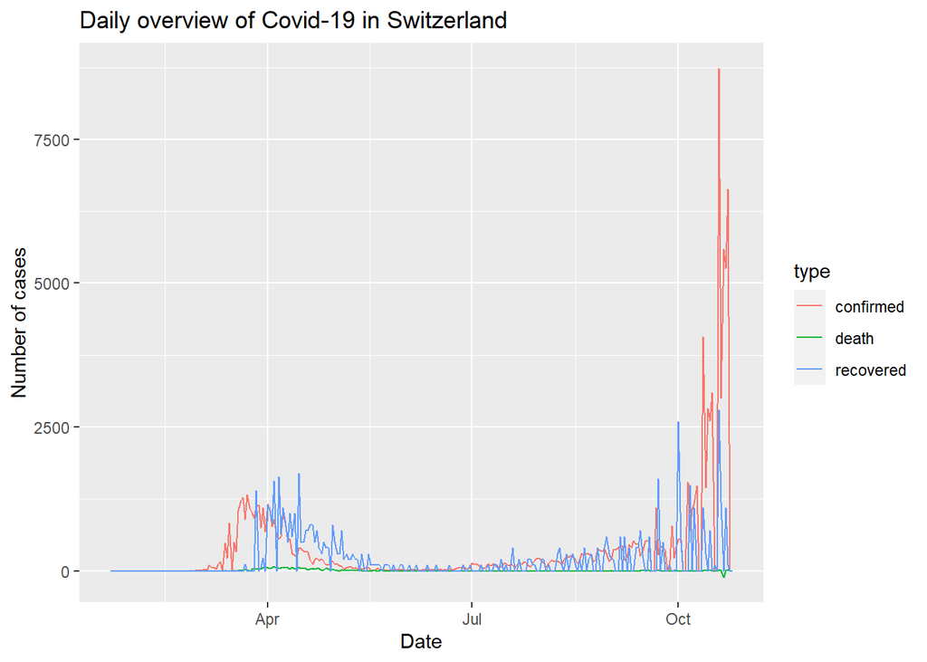

```r
# show Swiss plot
ch.plot_overview
```

Testing seems to happen sporadically (with many days where 0 cases are recorded). To get a better view, let’s take a look at just the days when we ignore the days without any cases.

```r
# construct Swiss plot
ch.plot_overview.no_zero <-
  ggplot(
    data = ch.coronavirus %>% filter(cases != 0),
    mapping = aes(x = date, y = cases)
  ) +
  geom_line(
    mapping = aes(x = date, y = cases, group = type, col = type)
  ) +
  labs(
    title = "Daily overview of Covid-19 in Switzerland",
    x = "Date",
    y = "Number of cases"
  )
  NULL
```

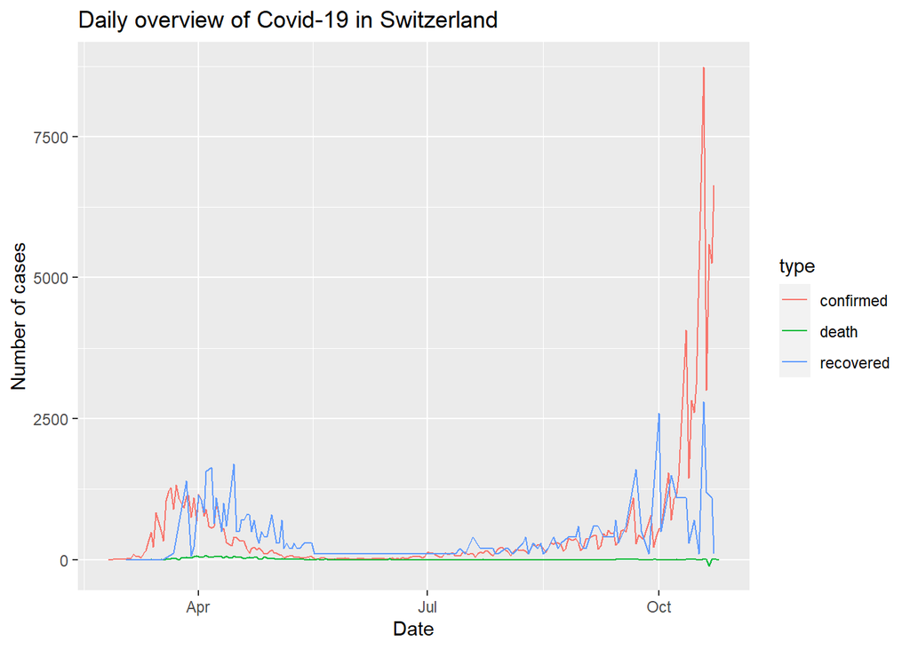

```r
# show Swiss plot
ch.plot_overview.no_zero
```

```r
# find the peak of confirmed cases during the first wave
ch.first_peak <- ch.coronavirus %>%
  filter(
    date > as.Date("2020-03-01")
    & date < as.Date("2020-06-01")
    & type == "confirmed"
  ) %>%
  summarize(
    peak = max(cases)
  )

# find the overall peak of confirmed cases
ch.overall_peak <- ch.coronavirus %>%
  filter(
    type == "confirmed"
  ) %>%
  summarize(
    peak = max(cases)
  )

# calculate the difference between the two peaks
ch.peak_comp <- ch.overall_peak$peak / ch.first_peak$peak
```

The current peak is much higher than the peak from the first wave. With 1321 cases in the first wave’s peak and 8737 cases in the most recent wave’s peak, the most recent peak has around 7 times more cases than the first peak.

# Per Capita Daily New Cases

Given that different countries have different sizes, it is pointless to compare the number of daily cases as is. The number of daily cases per capita is a more accurate way of comparing countries. More specifically, we will use the 7-day average daily cases per 100.000 inhabitants, excluding the most recent day, as a metric to compare countries.

```r
# load the country population data from the wpp2019 package
data("pop")

# mutate `pop` and `coronavirus` to use the same country names
pop$name <- countryname(pop$name, destination = "un.name.en")
coronavirus$country <- countryname(coronavirus$country, destination = "un.name.en")

# calculate the 7-day average daily cases per 100k inhabitants
country_per_captia_avg.coronavirus <- coronavirus %>%
  group_by(country) %>%
  filter(date != Sys.Date() & date >= Sys.Date() - 7 & type == "confirmed") %>%
  summarise(avg = mean(cases))
country_per_captia_avg.coronavirus <-
  merge(
    country_per_captia_avg.coronavirus,
    pop,
    by.x = "country",
    by.y = "name",
    all = FALSE
  ) %>%
  select(
    country,
    avg,
    pop_2020 = "2020"
  ) %>%
  # omit any NA values since these come from countries that are unknown/not in both datasets
  na.omit() %>%
  mutate(
    avg_per_100k = 100000 * avg / (pop_2020 * 1000)
  ) %>%
  arrange(
    desc(avg_per_100k)
  )

head(country_per_captia_avg.coronavirus, n = 10)
```

```
##           country     avg  pop_2020 avg_per_100k
## 1         Belgium 13529.0 11589.616    116.73381
## 2  Czech Republic 11891.0 10708.982    111.03763
## 3      Luxembourg   545.6   625.976     87.15989
## 4        Slovenia  1619.6  2078.932     77.90539
## 5         Armenia  2056.0  2963.234     69.38365
## 6     Switzerland  5866.0  8654.618     67.77884
## 7         Georgia  1819.0  3989.175     45.59840
## 8         Croatia  1784.2  4105.268     43.46123
## 9        Slovakia  2310.6  5459.643     42.32145
## 10          Spain 18605.0 46754.783     39.79272
```

The population (`pop_2020`) is listed in thousands, while the other values are listed in real values. As can be seen from the table above, Europe is once again one of the hardest hit countries by the second wave. The 10 worst countries in daily confirmed cases per capita are all European.